# esm_206_lab5_km

Keene Morrow

10/29/2019

#### Lab 5 Objectives

- Learn to aprse dates with `lubridate`
- Get counts of observations with count()
- Uncount() rows
- One- and two-sample t-tests
- Create heatmap with geom_tile()

Use tidyr::uncount() to convert lobster data from frequency format to case format (aka, taking the lobster_count column and replicating each row the correct number of times to have one row per lobster found lobster_count = 0 results in no rows of that data. If those were necessary, complete_cases could be used)

```r
lobster_tidy <- lobster_abundance %>%
  tidyr::uncount(lobster_count)
```

#### Exploraty Data Visualization

Considering site as variable of interest

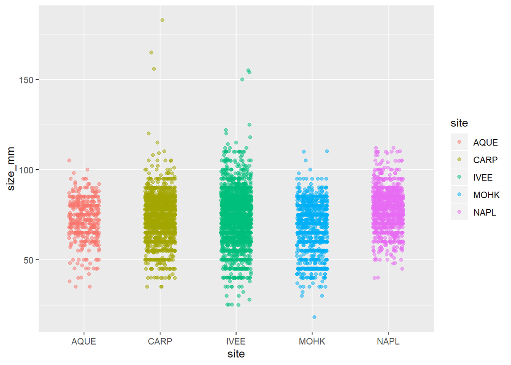

```r
ggplot(lobster_tidy, aes(x = site, y = size_mm)) +
  geom_jitter(aes(color = site),
              alpha = 0.5,
              width = 0.2)
```

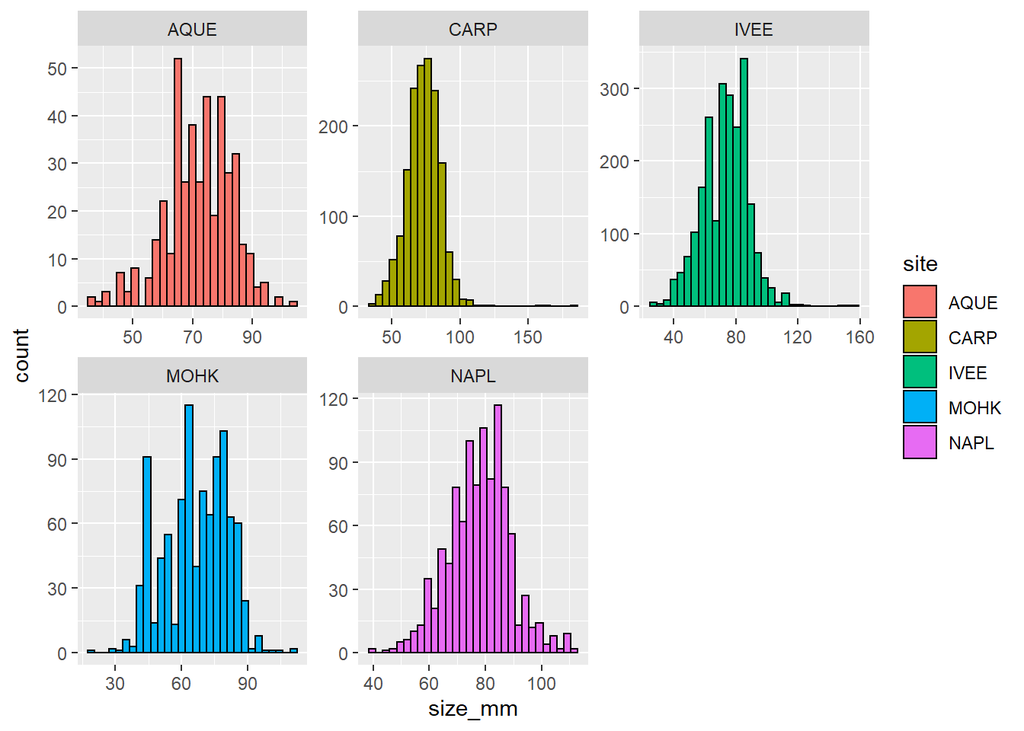

```r
ggplot(lobster_tidy, aes(x = size_mm)) +
  geom_histogram(aes(fill = site),
                     color = "black") +
  facet_wrap(~site, scales = "free")
```

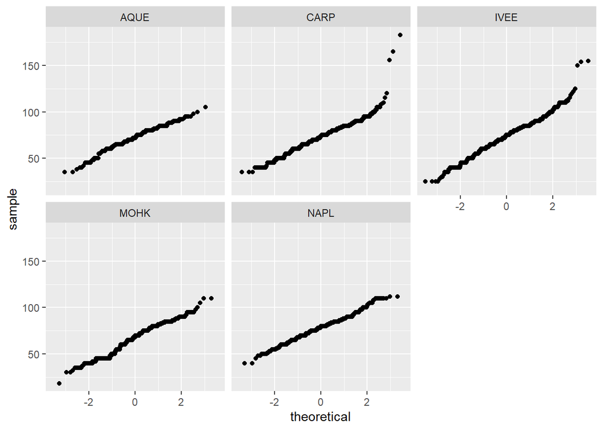

```r
# scales = "free" removes the identical scale across the facets (can be used to make something ireesponsible)

ggplot(lobster_tidy, aes(sample = size_mm)) +
  geom_qq() + # default comparison is to normal distribution, but there are plenty of other options if needed
  facet_wrap(~site)
```

#### Convert ‘date’ column to class ‘Data’

We’ll use the `lubridate` package to convert to date format and then to parse month and year

```r
lobster_date <- lobster_tidy %>%
  mutate(
    date_new = lubridate::mdy(date)
  )
```

Then we’ll use the lubridate::month and lubridate::year functions to to parse the month and year

```r
lobster_parse_date <- lobster_date %>%
  mutate(
    obs_month = lubridate::month(date_new, label = TRUE),
    obs_year = lubridate::year(date_new)
  )
```

Now Let’s find counts of observed lobstars based on different hierarchical groupings:

First, let’s count lobsters by year and month

```r
lobster_ym <- lobster_parse_date %>%
  dplyr::count(obs_year, obs_month)

lobster_ym
```

```
## # A tibble: 8 x 3
##   obs_year obs_month     n
##      <dbl> <ord>     <int>
## 1     2012 Aug         231
## 2     2013 Aug         243
## 3     2014 Aug         404
## 4     2014 Sep         106
## 5     2015 Aug        1100
## 6     2016 Aug         809
## 7     2017 Aug        1668
## 8     2018 Aug        1805
```

```r
lobster_y <- lobster_parse_date %>%
  dplyr::count(obs_year)

lobster_y
```

```
## # A tibble: 7 x 2
##   obs_year     n
##      <dbl> <int>
## 1     2012   231
## 2     2013   243
## 3     2014   510
## 4     2015  1100
## 5     2016   809
## 6     2017  1668
## 7     2018  1805
```

```r
lobster_site <- lobster_parse_date %>%
  dplyr::count(site)

lobster_site
```

```
## # A tibble: 5 x 2
##   site      n
##   <chr> <int>
## 1 AQUE    422
## 2 CARP   1619
## 3 IVEE   2304
## 4 MOHK    982
## 5 NAPL   1039
```

If we want to create a sumamry table that contains statistics other than count by group, it’s easier to use group_by() + n()

```r
lobster_summary <- lobster_parse_date %>%
  group_by(site) %>%
  summarize(
    lobster_number = n(),
    mean_size = mean(size_mm, na.rm = TRUE),
    sd_size = sd(size_mm, na.rm = TRUE)
  )

lobster_summary
```

```
## # A tibble: 5 x 4
##   site  lobster_number mean_size sd_size
##   <chr>          <int>     <dbl>   <dbl>
## 1 AQUE             422      72.3    11.4
## 2 CARP            1619      72.8    12.5
## 3 IVEE            2304      73.6    14.4
## 4 MOHK             982      66.9    14.2
## 5 NAPL            1039      78.2    11.1
```

#### Find confidence intervals

Use t.test() function to find confidenc eitnerval (for one sample) and perform t-tests to compate means of two samples

```r
ivee_lobsters <- lobster_tidy %>%
  filter(site == "IVEE") %>%
  pull(size_mm) # pulls out vector of one variable

t.test(ivee_lobsters)
```

```
##
##  One Sample t-test
##
## data:  ivee_lobsters
## t = 245.23, df = 2302, p-value < 2.2e-16
## alternative hypothesis: true mean is not equal to 0
## 95 percent confidence interval:
##  72.99130 74.16806
## sample estimates:
## mean of x
##  73.57968
```

#### 2 sample t-test to compare means:

Is there a significant difference between lobster sizes observed at Naples reef versus lobsters observed at Mohawk reef? If they’re from the same population and perfect smaples, the difference will be zero. Follow up: are the means different enough to support whether or not the samples are from two different populations?

We’ve done our necessary exploratory analyses (look to be normally distributed, large n) in order to determine that a 2-sample t-test for means comaprison is appropriate.

```r
napl_sample <- lobster_tidy %>%
  filter(site == "NAPL") %>%
  pull(size_mm)

mohk_sample <- lobster_tidy %>%
  filter(site == "MOHK") %>%
  pull(size_mm)

mn_ttest <- t.test(napl_sample, mohk_sample)
mn_ttest
```

```
##
##  Welch Two Sample t-test
##
## data:  napl_sample and mohk_sample
## t = 19.849, df = 1850.8, p-value < 2.2e-16
## alternative hypothesis: true difference in means is not equal to 0
## 95 percent confidence interval:
##  10.19806 12.43436
## sample estimates:
## mean of x mean of y
##  78.18454  66.86833
```

```r
lobster_mn <- lobster_tidy %>%
  filter(site %in% c("NAPL", "MOHK"))

mn_ttest2 <- t.test(size_mm ~ site, data = lobster_mn) # ~ = as a function of... different levels in the site column

mn_ttest2
```

```
##
##  Welch Two Sample t-test
##
## data:  size_mm by site
## t = -19.849, df = 1850.8, p-value < 2.2e-16
## alternative hypothesis: true difference in means is not equal to 0
## 95 percent confidence interval:
##  -12.43436 -10.19806
## sample estimates:
## mean in group MOHK mean in group NAPL
##           66.86833           78.18454
```

There is a significant difference in lobster lengths between Naples and Mohawk Reefs. (t(df) = -19.85, p < 0.001, alpha = 0.05).